# World Hapiness

Mohsen Bahremani

11/9/2020

This analysis is about World Happiness at 2017 to 2019.

These two question will be analysis in this project: What is the trend in Happiness in Worldwide and region-wise? What is/are the most important factor(s) of happiness?

```r
library(tidyverse)
```

The datasets used in this file are available on Kaggle. The data comes from the Gallup World Poll. https://www.kaggle.com/unsdsn/world-happiness

Data import: There are five separate datasets - 2015 to 2019. I chose three of them.

```r
df17 <- read_csv("2017.csv")
df18 <- read_csv("2018.csv")
df19 <- read_csv("2019.csv")
df18
```

```
## # A tibble: 156 x 9
##    `Overall rank` `Country or region` Score `GDP per capita` `Social support`
##             <dbl> <chr>               <dbl>            <dbl>            <dbl>
##  1              1 Finland              7.63             1.30             1.59
##  2              2 Norway               7.59             1.46             1.58
##  3              3 Denmark              7.56             1.35             1.59
##  4              4 Iceland              7.50             1.34             1.64
##  5              5 Switzerland          7.49             1.42             1.55
##  6              6 Netherlands          7.44             1.36             1.49
##  7              7 Canada               7.33             1.33             1.53
##  8              8 New Zealand          7.32             1.27             1.60
##  9              9 Sweden               7.31             1.36             1.50
## 10             10 Australia            7.27             1.34             1.57
## # … with 146 more rows, and 4 more variables: Healthy life expectancy <dbl>,
## #   Freedom to make life choices <dbl>, Generosity <dbl>,
## #   Perceptions of corruption <chr>
```

According to the data definition on kaggle, I am also interested in the columns for Economy (GDP per capita), Family, Health (Life Expectancy), Freedom, Trust (Absence of Government Corruption), and Generosity. These are the six factors of happiness included in the survey. The values in these columns indicate how much each of the factors contributed to the overall happiness score for each country, i.e. how important they were.

I addition country and happiness score are selected.

The relevant columns in the 2017 dataset are selected:

```r
df17 <- df17 %>% select('Country', 'Happiness.Rank', 'Happiness.Score', 'Economy..GDP.per.Capita.', 'Family', 'Health..Life.Expectancy.','Freedom', 'Trust..Government.Corruption.', Generosity)
```

Also 2018

```r
df18 <- df18 %>% select('Country or region', 'Overall rank', 'Score', 'GDP per capita', 'Social support', 'Healthy life expectancy', 'Freedom to make life choices', 'Perceptions of corruption', Generosity)
```

Finally 2019

```r
df19 <- df19 %>% select('Country or region', 'Overall rank', 'Score', 'GDP per capita', 'Social support', 'Healthy life expectancy', 'Freedom to make life choices', 'Perceptions of corruption', Generosity)
```

I wnat to seprate coutried in small groups by using countrycode, this package helps us to code and decode country and return translation, region and so on. you can look at ?countrycode , ?codelist or https://cran.r-project.org/web/packages/countrycode/countrycode.pdf

install.packages(‘countrycode’) If it is needed

```r
?countrycode
```

```
## No documentation for 'countrycode' in specified packages and libraries:
## you could try '??countrycode'
```

```r
?codelist
```

```
## No documentation for 'codelist' in specified packages and libraries:
## you could try '??codelist'
```

```r
library(countrycode)
df19 <- df19 %>%
                 mutate('region' =countrycode(df19$`Country or region`, 'country.name', 'region') )
```

```r
df18 <- df18 %>%
                 mutate('region' =countrycode(df18$`Country or region`, 'country.name', 'region') )
df17 <- df17 %>%
                 mutate('region' =countrycode(df17$`Country`, 'country.name', 'region') )
```

## Data Analysis

Here’s a world map color-coded by each country’s overall happiness score in 2017.

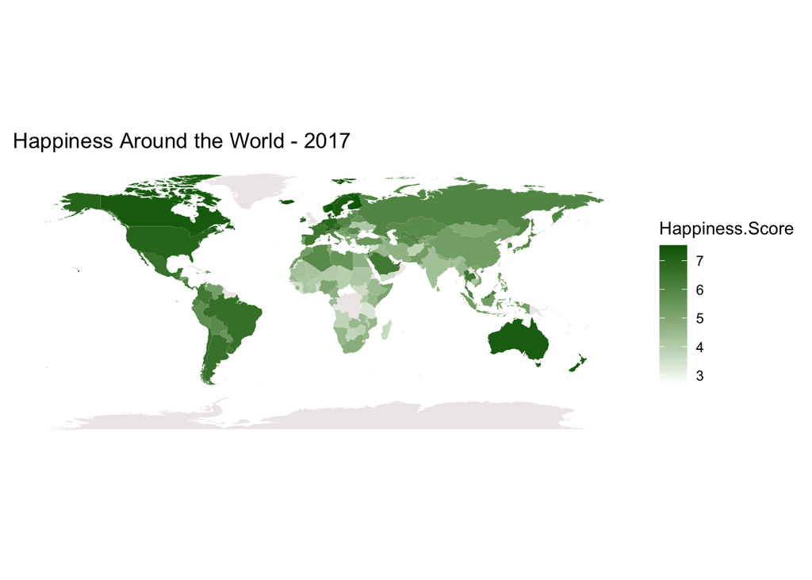

```r
worldmap <- map_data("world")
names(worldmap)[names(worldmap)=="region"] <- "Country"
worldmap$Country[worldmap$Country == "USA"] <- "United States"
happy_world <- df17 %>%
  full_join(worldmap, by = "Country")

map_theme <- theme(
    axis.title.x = element_blank(),
    axis.text.x  = element_blank(),
    axis.ticks.x = element_blank(),
    axis.title.y = element_blank(),
    axis.text.y  = element_blank(),
    axis.ticks.y = element_blank(),
    panel.background = element_rect(fill = "white"))

ggplot(data = happy_world, mapping = aes(x = long, y = lat, group = group)) +
  geom_polygon(aes(fill = `Happiness.Score`))  +
  scale_fill_continuous(low="white", high="darkgreen", na.value="snow2") +
  coord_quickmap() +
  labs(title = "Happiness Around the World - 2017") +
  map_theme
```

Region-wise table by the average of score give us some leads too:

```r
 df_average <- df17 %>%
                select(region, `Happiness.Score`) %>%
                group_by(region) %>%
                summarize(Average = mean(`Happiness.Score`)) %>%
                arrange(desc(Average))
 df_average
```

```
## # A tibble: 7 x 2
##   region                     Average
##   <chr>                        <dbl>
## 1 North America                 7.15
## 2 Latin America & Caribbean     5.96
## 3 Europe & Central Asia         5.93
## 4 East Asia & Pacific           5.75
## 5 Middle East & North Africa    5.42
## 6 South Asia                    4.63
## 7 Sub-Saharan Africa            4.11
```

It is comparison among region at 2017:

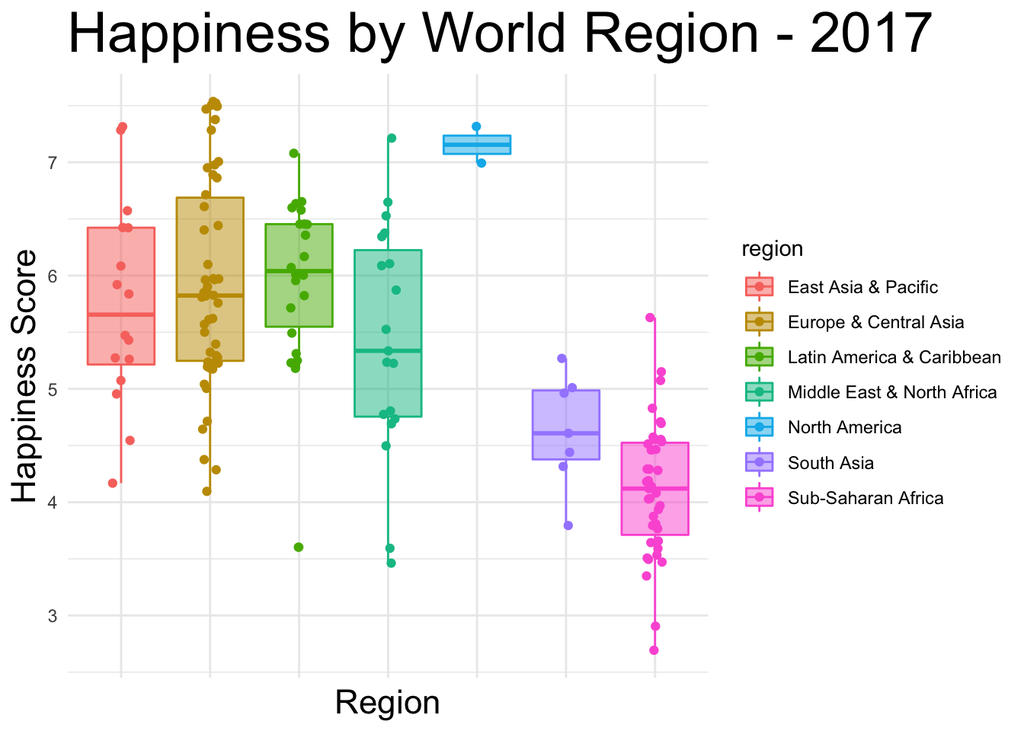

```r
ggplot(data = df17, aes(x = region, y = `Happiness.Score`)) +
  geom_boxplot(aes(color = region, fill = region), alpha = 0.5) +
  geom_point(aes(color = region), position = position_jitter(width = .1)) +
  labs(title = "Happiness by World Region - 2017",
       x = "Region",
       y = "Happiness Score") +
  theme_minimal() +
  theme(plot.title = element_text(size = rel(2.5)),
        axis.title = element_text(size = rel(1.5)),
        axis.text.x = element_blank())
```

boxplot and table share the same idea regarding what I mentioned before. North american has higer average and Sub-Saharan Africa has the lowest average, next to Southern Asia.

We can make similar boxplots for 2018 and 2019.

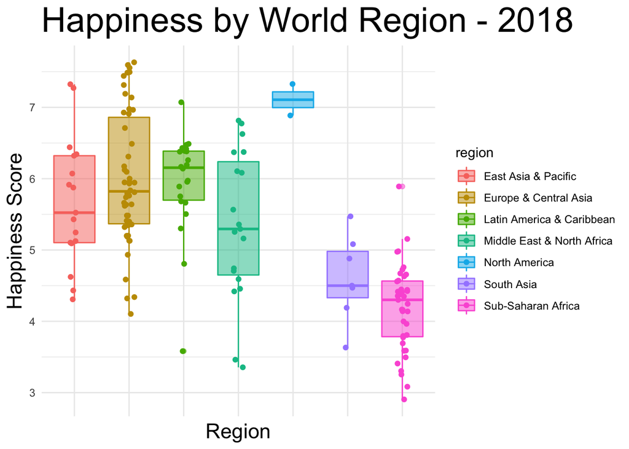

```r
ggplot(data = df18, aes(x = region, y = `Score`)) +
  geom_boxplot(aes(color = region, fill = region), alpha = 0.5) +
  geom_point(aes(color = region), position = position_jitter(width = .1)) +
  labs(title = "Happiness by World Region - 2018",
       x = "Region",
       y = "Happiness Score") +
  theme_minimal() +
  theme(plot.title = element_text(size = rel(2.5)),
        axis.title = element_text(size = rel(1.5)),
        axis.text.x = element_blank())
```

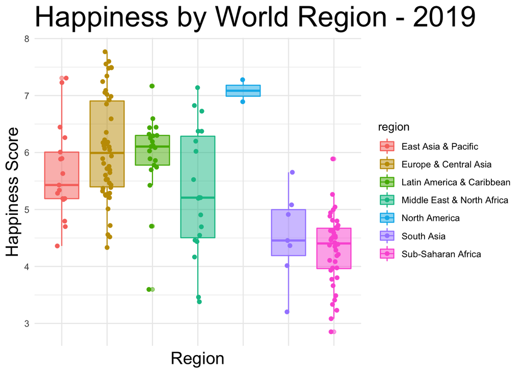

```r
ggplot(data = df19, aes(x = region, y = `Score`)) +
  geom_boxplot(aes(color = region, fill = region), alpha = 0.5) +
  geom_point(aes(color = region), position = position_jitter(width = .1)) +
  labs(title = "Happiness by World Region - 2019",
       x = "Region",
       y = "Happiness Score") +
  theme_minimal() +
  theme(plot.title = element_text(size = rel(2.5)),
        axis.title = element_text(size = rel(1.5)),
        axis.text.x = element_blank())
```

Let’s look at how happiness scores changed for each country over time.

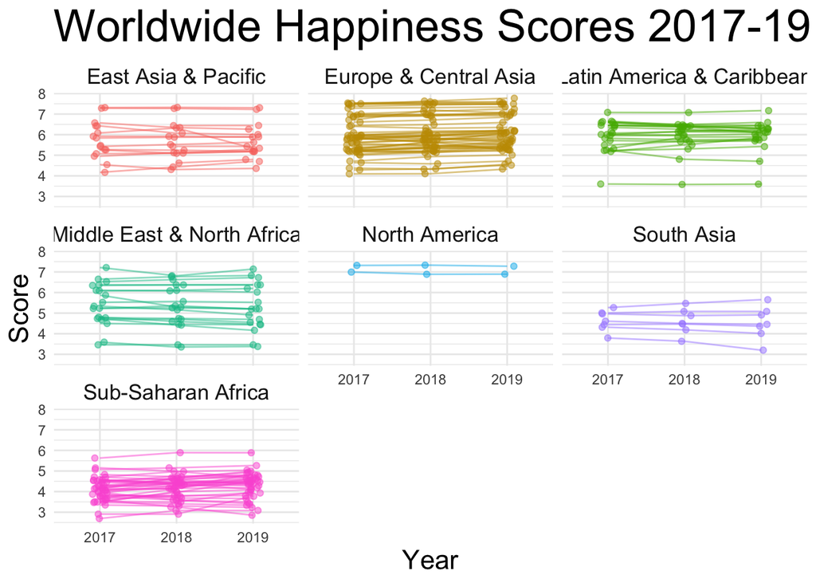

```r
df17$year <- "2017"
df18$year <- "2018"
df19$year <- "2019"

names(df17)[names(df17)=="Happiness.Score"] <- "score"
names(df18)[names(df18)=="Score"] <- "score"
names(df19)[names(df19)=="Score"] <- "score"

names(df18)[names(df18)=="Country or region"] <- "Country"
names(df19)[names(df19)=="Country or region"] <- "Country"

dfall <- rbind(select(df17,"Country", "region", "score", "year"),
               select(df18, "Country", "region", "score", "year"),
               select(df19, "Country", "region", "score", "year"))

ggplot(data = dfall) +
  geom_line(mapping = aes(x = year, y = score, group = Country,
                          color = region),
            alpha = 0.5, show.legend = FALSE) +
  geom_point(aes(x = year, y = score, color = region),
             position = position_jitter(width = .1),
             alpha = 0.5,
             show.legend = FALSE) +
  labs(title = "Worldwide Happiness Scores 2017-19",
       x = "Year",
       y = "Score") +
  theme_minimal() +
  theme(plot.title = element_text(size = rel(2.5)),
        axis.title = element_text(size = rel(1.5)),
        strip.text.x = element_text(size = rel(1.5))) +
  facet_wrap(~ region)
```

As it is obvious, there is no significant change through years.Just very few countries whose scores decreased significantly, and fewer still whose scores increased significantly.

## Explanatory variables

At this section, I want to describe how the factors have an effect on score(just linear relation):

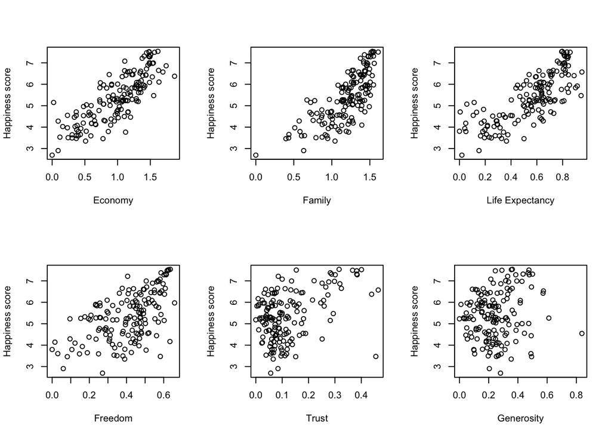

```r
par(mfrow = c(2,3))
plot(df17$Economy..GDP.per.Capita.,df17$score, xlab = "Economy" , ylab ="Happiness score" )
plot(df17$Family,df17$score,xlab ="Family" , ylab = "Happiness score" )
plot(df17$Health..Life.Expectancy.,df17$score,xlab = "Life Expectancy", ylab = "Happiness score" )
plot(df17$Freedom,df17$score,xlab ="Freedom" , ylab ="Happiness score"  )
plot(df17$Trust..Government.Corruption.,df17$score,xlab = "Trust" , ylab = "Happiness score" )
plot(df17$Generosity,df17$score,xlab = "Generosity" , ylab ="Happiness score"  )
```

```r
#plot(log(df17$Trust..Government.Corruption.),log(df17$score),xlab = "Trust" , ylab = "Happiness score" )
#plot(log(df17$Generosity),log(df17$score),xlab = "Generosity" , ylab ="Happiness score"  )
```

```r
#library(corrplot)
#corrplot(cor(df17), addCoef.col = "white", addCoefasPercent=T, type="upper", order="FPC")
```

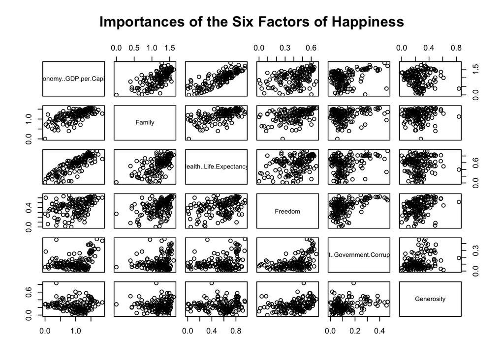

```r
pairs(~Economy..GDP.per.Capita.+Family+Health..Life.Expectancy.+Freedom+Trust..Government.Corruption.+Generosity, data = df17,
      main="Importances of the Six Factors of Happiness")
```

These plots illustrate that first four factor have significant? relation to score, but last two of them do not show obvious pattern.

And also, first row plot are stronger linearity compared to Freedom.

```r
model.fit= lm(score~Economy..GDP.per.Capita.+Family+Health..Life.Expectancy.+Freedom+Trust..Government.Corruption.+Generosity, data = df17)
summary(model.fit)
```

```
##
## Call:
## lm(formula = score ~ Economy..GDP.per.Capita. + Family + Health..Life.Expectancy. +
##     Freedom + Trust..Government.Corruption. + Generosity, data = df17)
##
## Residuals:
##      Min       1Q   Median       3Q      Max
## -1.52798 -0.25219 -0.02277  0.28526  1.20417
##
## Coefficients:
##                               Estimate Std. Error t value Pr(>|t|)
## (Intercept)                     1.7430     0.1874   9.303  < 2e-16 ***
## Economy..GDP.per.Capita.        0.7844     0.2045   3.836 0.000185 ***
## Family                          1.1178     0.2021   5.532 1.40e-07 ***
## Health..Life.Expectancy.        1.2889     0.3215   4.009 9.65e-05 ***
## Freedom                         1.4757     0.3425   4.309 2.98e-05 ***
## Trust..Government.Corruption.   0.8266     0.4843   1.707 0.089975 .
## Generosity                      0.3807     0.3293   1.156 0.249524
## ---
## Signif. codes:  0 '***' 0.001 '**' 0.01 '*' 0.05 '.' 0.1 ' ' 1
##
## Residual standard error: 0.4998 on 148 degrees of freedom
## Multiple R-squared:  0.8124, Adjusted R-squared:  0.8048
## F-statistic: 106.8 on 6 and 148 DF,  p-value: < 2.2e-16
```

As correlation showed: Trust and Generosity do not have linear relation to score. Other type of relation like log , quadratic should be checked.

Let’s take a closer look at the top 10 happiest countries in 2017 and how much each of the six factors contributed toward their overall happiness scores. For this, a stacked bar plot would be a useful visualization.

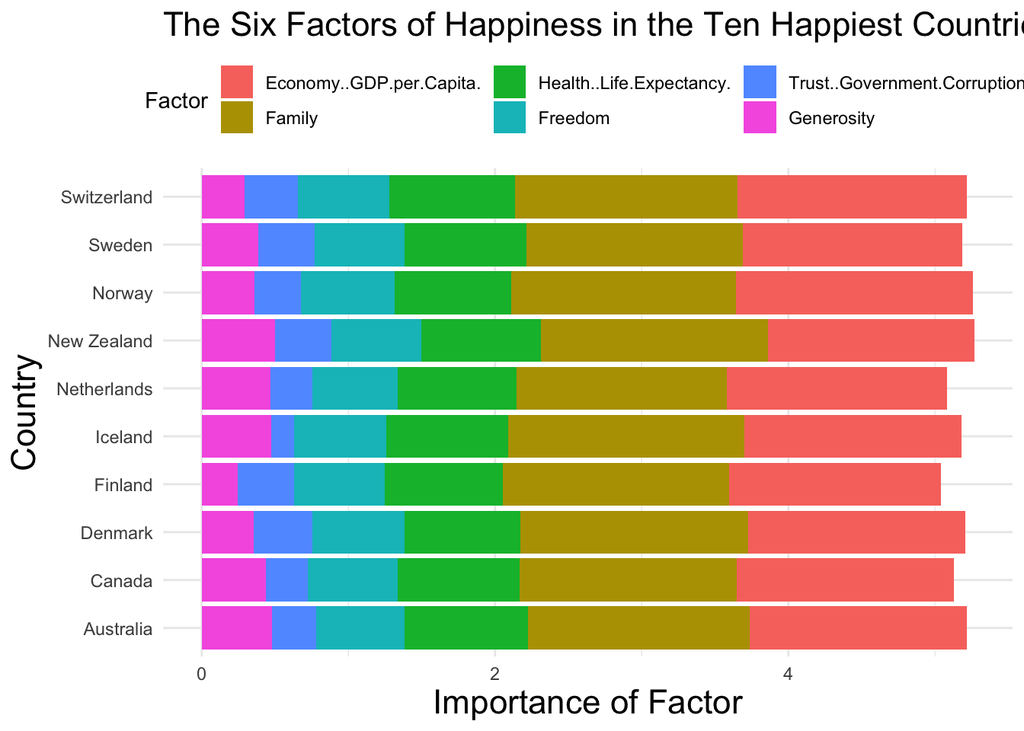

```r
dfwide <- df17 %>%
          head(10)

dflong <- gather(dfwide, Factor, `Importance of Factor`, Economy..GDP.per.Capita.:Generosity, factor_key=TRUE)

ggplot(data = dflong) +
  geom_bar(stat = "identity",
           aes(x = Country, y = `Importance of Factor`, fill = Factor)) +
  coord_flip() +
  theme_minimal() +
  theme(legend.position = "top") +
  labs(title = "The Six Factors of Happiness in the Ten Happiest Countries") +
  theme(plot.title = element_text(size = rel(1.5)),
        axis.title = element_text(size = rel(1.5)))
```

In general, Economy and Family seem to the the two most important factors of happiness in these countries. Trust (absence of corruption) and Generosity are the least important.